# Binary-Class Tabular Model for Kaggle Playground Series Season 3 Episode 3 Using Python and TensorFlow Decision Forests

### January 31, 2023

SUMMARY: The project aims to construct a predictive model using various machine learning algorithms and document the end-to-end steps using a template. The Kaggle Playground Series Season 3 Episode 3 dataset is a binary-class modeling situation where we attempt to predict one of two possible outcomes.

INTRODUCTION: Kaggle wants to provide an approachable environment for relatively new people in their data science journey. Since January 2021, they have hosted playground-style competitions to give the Kaggle community a variety of reasonably lightweight challenges that can be used to learn and sharpen skills in different aspects of machine learning and data science. The dataset for this competition was generated from a deep learning model trained on the IBM HR Analytics Employee Attrition & Performance dataset. Feature distributions are close to but different from the original.

ANALYSIS: The Random Forest model performed the best with the training dataset. The model achieved an AUC/ROC benchmark of 0.9992. When we processed the test dataset with the final model, the model achieved an AUC/ROC score of 0.8734.

CONCLUSION: In this iteration, the Random Forest model appeared to be a suitable algorithm for modeling this dataset.

Dataset Used: Playground Series Season 3, Episode 3

Dataset ML Model: Binary-Class classification with numerical and categorical features

Dataset Reference: https://www.kaggle.com/competitions/playground-series-s3e3

One source of potential performance benchmarks: https://www.kaggle.com/competitions/playground-series-s3e3/leaderboard

## Task 1 - Prepare Environment

```python
# Install TensorFlow Decision Forests
!pip3 install tensorflow_decision_forests --upgrade
```

[output not shown]

```python
# Retrieve the CPU information
ncpu = !nproc
print("The number of available CPUs is:", ncpu[0])
```

```
The number of available CPUs is: 2
```

### 1.a) Load libraries and modules

```python
# Set the random seed number for reproducible results
RNG_SEED = 888
```

```python
import random
random.seed(RNG_SEED)
import numpy as np
np.random.seed(RNG_SEED)
import pandas as pd
import seaborn as sns
import matplotlib
import matplotlib.pyplot as plt
import os
import sys
import math
# import boto3
import zipfile
import urllib
from datetime import datetime
from sklearn import preprocessing
from sklearn.model_selection import train_test_split
from sklearn.model_selection import RepeatedKFold
from sklearn.metrics import classification_report
from sklearn.metrics import confusion_matrix
from sklearn.metrics import accuracy_score
from sklearn.pipeline import Pipeline
from sklearn import compose
from sklearn import impute
from sklearn import metrics
import tensorflow as tf
tf.random.set_seed(RNG_SEED)
# from tensorflow import keras
import tensorflow_decision_forests as tfdf
```

### 1.b) Set up the controlling parameters and functions

```python
# Begin the timer for the script processing
start_time_script = datetime.now()

# Set up the number of CPU cores available for multi-thread processing
N_JOBS = 1

# Set up the flag to stop sending progress emails (setting to True will send status emails!)
NOTIFY_STATUS = False

# Set the percentage sizes for splitting the dataset
TEST_SET_RATIO = 0.1
VAL_SET_RATIO = 0.1

# Set the name for the class/label column
ORIGINAL_LABEL = 'Attrition'
CLASS_COLUMN = 'target'

# Set the number of folds for cross validation
N_FOLDS = 10
N_ITERATIONS = 1

# Set default modeling scoring metric
DEFAULT_METRICS = [tf.keras.metrics.AUC()]

# Define the directory locations and file names
ORIGINAL_DATASET = 'https://dainesanalytics.com/datasets/kaggle-playground-series-s3e03/WA_Fn-UseC_-HR-Employee-Attrition.csv'
TRAIN_DATASET = 'https://dainesanalytics.com/datasets/kaggle-playground-series-s3e03/train.csv'
TEST_DATASET = 'https://dainesanalytics.com/datasets/kaggle-playground-series-s3e03/test.csv'
SUBMISSION_TEMPLATE = 'https://dainesanalytics.com/datasets/kaggle-playground-series-s3e03/sample_submission.csv'
SUBMISSION_FILE = 'submission_decisionforests_'

# Print out the TensorFlow version for confirmation
print('TensorFlow version:', tf.__version__)

# Check the version of TensorFlow Decision Forests
print("Found TensorFlow Decision Forests v" + tfdf.__version__)
```

```
TensorFlow version: 2.11.0
Found TensorFlow Decision Forests v1.2.0
```

```python
# Set up the email notification function
def status_notify(msg_text):
    access_key = os.environ.get('SNS_ACCESS_KEY')
    secret_key = os.environ.get('SNS_SECRET_KEY')
    aws_region = os.environ.get('SNS_AWS_REGION')
    topic_arn = os.environ.get('SNS_TOPIC_ARN')
    if (access_key is None) or (secret_key is None) or (aws_region is None):
        sys.exit("Incomplete notification setup info. Script Processing Aborted!!!")
    sns = boto3.client('sns', aws_access_key_id=access_key, aws_secret_access_key=secret_key, region_name=aws_region)
    response = sns.publish(TopicArn=topic_arn, Message=msg_text)
    if response['ResponseMetadata']['HTTPStatusCode'] != 200 :
        print('Status notification not OK with HTTP status code:', response['ResponseMetadata']['HTTPStatusCode'])
```

```python
if NOTIFY_STATUS: status_notify("Task 1 - Prepare Environment has begun! " + datetime.now().strftime('%a %B %d, %Y %I:%M:%S %p'))
```

### 1.c) Load dataset

```python
df_dataset_import = pd.read_csv(TRAIN_DATASET)

# Take a peek at the dataframe after import
print(df_dataset_import.head())
```

```
   id  Age     BusinessTravel  DailyRate              Department  \
0   0   36  Travel_Frequently        599  Research & Development
1   1   35      Travel_Rarely        921                   Sales
2   2   32      Travel_Rarely        718                   Sales
3   3   38      Travel_Rarely       1488  Research & Development
4   4   50      Travel_Rarely       1017  Research & Development

   DistanceFromHome  Education EducationField  EmployeeCount  \
0                24          3        Medical              1
1                 8          3          Other              1
2                26          3      Marketing              1
3                 2          3        Medical              1
4                 5          4        Medical              1

   EnvironmentSatisfaction  ... StandardHours  StockOptionLevel  \
```

[output cut: 21 more lines]

```python
df_dataset_import.info(verbose=True)
```

```
<class 'pandas.core.frame.DataFrame'>
RangeIndex: 1677 entries, 0 to 1676
Data columns (total 35 columns):
 #   Column                    Non-Null Count  Dtype
---  ------                    --------------  -----
 0   id                        1677 non-null   int64
 1   Age                       1677 non-null   int64
 2   BusinessTravel            1677 non-null   object
 3   DailyRate                 1677 non-null   int64
 4   Department                1677 non-null   object
 5   DistanceFromHome          1677 non-null   int64
 6   Education                 1677 non-null   int64
 7   EducationField            1677 non-null   object
 8   EmployeeCount             1677 non-null   int64
 9   EnvironmentSatisfaction   1677 non-null   int64
```

[output cut: 27 more lines]

```python
print(df_dataset_import.describe())
```

```
                id          Age    DailyRate  DistanceFromHome    Education  \
count  1677.000000  1677.000000  1677.000000       1677.000000  1677.000000
mean    838.000000    36.036971   892.749553          8.683959     2.937984
std     484.252517     8.507112   374.496259          7.826143     1.039078
min       0.000000    18.000000   107.000000          1.000000     1.000000
25%     419.000000    30.000000   589.000000          2.000000     2.000000
50%     838.000000    35.000000   890.000000          7.000000     3.000000
75%    1257.000000    41.000000  1223.000000         12.000000     4.000000
max    1676.000000    60.000000  3921.000000         29.000000    15.000000

       EmployeeCount  EnvironmentSatisfaction   HourlyRate  JobInvolvement  \
count         1677.0              1677.000000  1677.000000     1677.000000
mean             1.0                 2.757901    67.798450        2.782349
std              0.0                 1.086835    19.435928        0.650664
min              1.0                 1.000000    30.000000        1.000000
25%              1.0                 2.000000    51.000000        2.000000
50%              1.0                 3.000000    69.000000        3.000000
75%              1.0                 4.000000    84.000000        3.000000
max              1.0                 4.000000   100.000000        4.000000

          JobLevel  ...  StandardHours  StockOptionLevel  TotalWorkingYears  \
count  1677.000000  ...         1677.0       1677.000000        1677.000000
mean      1.998807  ...           80.0          0.721527          10.709600
std       1.083065  ...            0.0          0.771259           7.255135
min       1.000000  ...           80.0          0.000000           0.000000
25%       1.000000  ...           80.0          0.000000           6.000000
50%       2.000000  ...           80.0          1.000000           9.000000
75%       2.000000  ...           80.0          1.000000          14.000000
max       7.000000  ...           80.0          3.000000          41.000000

       TrainingTimesLastYear  WorkLifeBalance  YearsAtCompany  \
count            1677.000000      1677.000000     1677.000000
mean                2.732856         2.769827        6.806798
std                 1.145271         0.647721        5.883282
min                 0.000000         1.000000        0.000000
25%                 2.000000         2.000000        3.000000
50%                 3.000000         3.000000        5.000000
75%                 3.000000         3.000000        9.000000
max                 6.000000         4.000000       41.000000

       YearsInCurrentRole  YearsSinceLastPromotion  YearsWithCurrManager  \
count         1677.000000              1677.000000           1677.000000
mean             4.144305                 1.978533              4.186643
std              3.583398                 3.045716              3.576189
min              0.000000                 0.000000              0.000000
25%              2.000000                 0.000000              2.000000
50%              3.000000                 1.000000              3.000000
75%              7.000000                 2.000000              7.000000
max             18.000000                15.000000             17.000000

         Attrition
count  1677.000000
mean      0.119261
std       0.324192
min       0.000000
25%       0.000000
50%       0.000000
75%       0.000000
max       1.000000

[8 rows x 27 columns]
```

```python
print(df_dataset_import.isnull().sum())
print('Total number of NaN in the dataframe: ', df_dataset_import.isnull().sum().sum())
```

```
id                          0
Age                         0
BusinessTravel              0
DailyRate                   0
Department                  0
DistanceFromHome            0
Education                   0
EducationField              0
EmployeeCount               0
EnvironmentSatisfaction     0
Gender                      0
HourlyRate                  0
JobInvolvement              0
JobLevel                    0
JobRole                     0
JobSatisfaction             0
MaritalStatus               0
MonthlyIncome               0
MonthlyRate                 0
NumCompaniesWorked          0
Over18                      0
OverTime                    0
PercentSalaryHike           0
PerformanceRating           0
RelationshipSatisfaction    0
StandardHours               0
StockOptionLevel            0
TotalWorkingYears           0
TrainingTimesLastYear       0
WorkLifeBalance             0
YearsAtCompany              0
YearsInCurrentRole          0
YearsSinceLastPromotion     0
YearsWithCurrManager        0
Attrition                   0
dtype: int64
Total number of NaN in the dataframe:  0
```

```python
# Get grouping size for the target variable
print(df_dataset_import.groupby(ORIGINAL_LABEL).size())
```

```
Attrition
0    1477
1     200
dtype: int64
```

### 1.d) Data Cleaning

```python
def clean_Attrition(target_col):
    # print(target_col)
    if target_col == 'Yes':
        return 1
    else:
        return 0
```

```python
# Fetch the original dataset and use it to supplement the training
df_dataset_original = pd.read_csv(ORIGINAL_DATASET)
df_dataset_original.pop('EmployeeNumber')
df_dataset_original.insert(len(df_dataset_original.columns)-1, 'Attrition', df_dataset_original.pop('Attrition'))
df_dataset_original['Attrition'] = df_dataset_original['Attrition'].apply(clean_Attrition)
# df_dataset_original['is_synthetic'] = 0

# Take a peek at the dataframe after import
print(df_dataset_original.head())
```

```
   Age     BusinessTravel  DailyRate              Department  \
0   41      Travel_Rarely       1102                   Sales
1   49  Travel_Frequently        279  Research & Development
2   37      Travel_Rarely       1373  Research & Development
3   33  Travel_Frequently       1392  Research & Development
4   27      Travel_Rarely        591  Research & Development

   DistanceFromHome  Education EducationField  EmployeeCount  \
0                 1          2  Life Sciences              1
1                 8          1  Life Sciences              1
2                 2          2          Other              1
3                 3          4  Life Sciences              1
4                 2          1        Medical              1

   EnvironmentSatisfaction  Gender  ...  StandardHours  StockOptionLevel  \
```

[output cut: 21 more lines]

```python
df_dataset_original.info(verbose=True)
```

```
<class 'pandas.core.frame.DataFrame'>
RangeIndex: 1470 entries, 0 to 1469
Data columns (total 34 columns):
 #   Column                    Non-Null Count  Dtype
---  ------                    --------------  -----
 0   Age                       1470 non-null   int64
 1   BusinessTravel            1470 non-null   object
 2   DailyRate                 1470 non-null   int64
 3   Department                1470 non-null   object
 4   DistanceFromHome          1470 non-null   int64
 5   Education                 1470 non-null   int64
 6   EducationField            1470 non-null   object
 7   EmployeeCount             1470 non-null   int64
 8   EnvironmentSatisfaction   1470 non-null   int64
 9   Gender                    1470 non-null   object
```

[output cut: 26 more lines]

```python
# Combine the original and synthetic datasets into one training dataset
df_dataset_import.pop('id')
# df_dataset_import['is_synthetic'] = 1

df_dataset_import = pd.concat([df_dataset_import, df_dataset_original],
                              ignore_index=True)

df_dataset_import.info(verbose=True)
```

```
<class 'pandas.core.frame.DataFrame'>
RangeIndex: 3147 entries, 0 to 3146
Data columns (total 34 columns):
 #   Column                    Non-Null Count  Dtype
---  ------                    --------------  -----
 0   Age                       3147 non-null   int64
 1   BusinessTravel            3147 non-null   object
 2   DailyRate                 3147 non-null   int64
 3   Department                3147 non-null   object
 4   DistanceFromHome          3147 non-null   int64
 5   Education                 3147 non-null   int64
 6   EducationField            3147 non-null   object
 7   EmployeeCount             3147 non-null   int64
 8   EnvironmentSatisfaction   3147 non-null   int64
 9   Gender                    3147 non-null   object
```

[output cut: 26 more lines]

```python
# Standardize the class column to the name of targetVar if required
df_dataset_import = df_dataset_import.rename(columns={ORIGINAL_LABEL: CLASS_COLUMN})

# Drop the columns that has no predictive value
df_dataset_import.drop(columns=['EmployeeCount','StandardHours'], inplace=True)

# Apply additional feature engineering tasks suggested by the top competitor
df_dataset_import['MonthlyIncome/Age'] = df_dataset_import['MonthlyIncome'] / df_dataset_import['Age']
df_dataset_import["Age_risk"] = (df_dataset_import["Age"] < 34).astype(int)
df_dataset_import["HourlyRate_risk"] = (df_dataset_import["HourlyRate"] < 60).astype(int)
df_dataset_import["Distance_risk"] = (df_dataset_import["DistanceFromHome"] >= 20).astype(int)
df_dataset_import["YearsAtCo_risk"] = (df_dataset_import["YearsAtCompany"] < 4).astype(int)
df_dataset_import['NumCompaniesWorked'] = df_dataset_import['NumCompaniesWorked'].replace(0, 1)
df_dataset_import['AverageTenure'] = df_dataset_import["TotalWorkingYears"] / df_dataset_import["NumCompaniesWorked"]
df_dataset_import['JobHopper'] = ((df_dataset_import["NumCompaniesWorked"] > 2) & (df_dataset_import["AverageTenure"] < 2.0)).astype(int)
df_dataset_import["AttritionRisk"] = df_dataset_import["Age_risk"] + df_dataset_import["HourlyRate_risk"] + df_dataset_import["Distance_risk"] + df_dataset_import["YearsAtCo_risk"] + df_dataset_import['JobHopper']

# Take a peek at the dataframe after cleaning
print(df_dataset_import.head())
print(df_dataset_import.tail())
```

```
   Age     BusinessTravel  DailyRate              Department  \
0   36  Travel_Frequently        599  Research & Development
1   35      Travel_Rarely        921                   Sales
2   32      Travel_Rarely        718                   Sales
3   38      Travel_Rarely       1488  Research & Development
4   50      Travel_Rarely       1017  Research & Development

   DistanceFromHome  Education EducationField  EnvironmentSatisfaction  \
0                24          3        Medical                        4
1                 8          3          Other                        1
2                26          3      Marketing                        3
3                 2          3        Medical                        3
4                 5          4        Medical                        2

   Gender  HourlyRate  ...  YearsWithCurrManager  target MonthlyIncome/Age  \
```

[output cut: 57 more lines]

```python
df_dataset_import.info(verbose=True)
```

```
<class 'pandas.core.frame.DataFrame'>
RangeIndex: 3147 entries, 0 to 3146
Data columns (total 40 columns):
 #   Column                    Non-Null Count  Dtype
---  ------                    --------------  -----
 0   Age                       3147 non-null   int64
 1   BusinessTravel            3147 non-null   object
 2   DailyRate                 3147 non-null   int64
 3   Department                3147 non-null   object
 4   DistanceFromHome          3147 non-null   int64
 5   Education                 3147 non-null   int64
 6   EducationField            3147 non-null   object
 7   EnvironmentSatisfaction   3147 non-null   int64
 8   Gender                    3147 non-null   object
 9   HourlyRate                3147 non-null   int64
```

[output cut: 32 more lines]

```python
print(df_dataset_import.describe())
```

```
               Age    DailyRate  DistanceFromHome    Education  \
count  3147.000000  3147.000000       3147.000000  3147.000000
mean     36.451223   850.586273          8.921513     2.926279
std       8.815861   390.859919          7.961278     1.032051
min      18.000000   102.000000          1.000000     1.000000
25%      30.000000   543.000000          2.000000     2.000000
50%      35.000000   852.000000          7.000000     3.000000
75%      42.000000  1198.500000         13.000000     4.000000
max      60.000000  3921.000000         29.000000    15.000000

       EnvironmentSatisfaction   HourlyRate  JobInvolvement     JobLevel  \
count              3147.000000  3147.000000     3147.000000  3147.000000
mean                  2.741023    66.907531        2.757865     2.029234
std                   1.089733    19.877918        0.680183     1.094590
min                   1.000000    30.000000        1.000000     1.000000
25%                   2.000000    50.000000        2.000000     1.000000
50%                   3.000000    67.000000        3.000000     2.000000
75%                   4.000000    84.000000        3.000000     3.000000
max                   4.000000   100.000000        4.000000     7.000000

       JobSatisfaction  MonthlyIncome  ...  YearsWithCurrManager       target  \
count      3147.000000    3147.000000  ...           3147.000000  3147.000000
mean          2.762313    6339.397521  ...              4.156975     0.138862
std           1.100224    4610.584686  ...              3.572003     0.345858
min           1.000000    1009.000000  ...              0.000000     0.000000
25%           2.000000    2888.000000  ...              2.000000     0.000000
50%           3.000000    4877.000000  ...              3.000000     0.000000
75%           4.000000    7725.000000  ...              7.000000     0.000000
max           4.000000   19999.000000  ...             17.000000     1.000000

       MonthlyIncome/Age     Age_risk  HourlyRate_risk  Distance_risk  \
count        3147.000000  3147.000000      3147.000000    3147.000000
mean          169.249028     0.397204         0.385764       0.143629
std           101.523449     0.489397         0.486853       0.350769
min            26.541667     0.000000         0.000000       0.000000
25%            93.027778     0.000000         0.000000       0.000000
50%           139.766667     0.000000         0.000000       0.000000
75%           215.508798     1.000000         1.000000       0.000000
max           660.956522     1.000000         1.000000       1.000000

       YearsAtCo_risk  AverageTenure    JobHopper  AttritionRisk
count     3147.000000    3147.000000  3147.000000    3147.000000
mean         0.324754       6.092536     0.140133       1.391484
std          0.468357       5.514808     0.347181       1.028780
min          0.000000       0.000000     0.000000       0.000000
25%          0.000000       2.071429     0.000000       1.000000
50%          0.000000       4.800000     0.000000       1.000000
75%          1.000000       9.000000     0.000000       2.000000
max          1.000000      41.000000     1.000000       5.000000

[8 rows x 32 columns]
```

```python
print(df_dataset_import.isnull().sum())
print('Total number of NaN in the dataframe: ', df_dataset_import.isnull().sum().sum())
```

```
Age                         0
BusinessTravel              0
DailyRate                   0
Department                  0
DistanceFromHome            0
Education                   0
EducationField              0
EnvironmentSatisfaction     0
Gender                      0
HourlyRate                  0
JobInvolvement              0
JobLevel                    0
JobRole                     0
JobSatisfaction             0
MaritalStatus               0
MonthlyIncome               0
MonthlyRate                 0
NumCompaniesWorked          0
Over18                      0
OverTime                    0
PercentSalaryHike           0
PerformanceRating           0
RelationshipSatisfaction    0
StockOptionLevel            0
TotalWorkingYears           0
TrainingTimesLastYear       0
WorkLifeBalance             0
YearsAtCompany              0
YearsInCurrentRole          0
YearsSinceLastPromotion     0
YearsWithCurrManager        0
target                      0
MonthlyIncome/Age           0
Age_risk                    0
HourlyRate_risk             0
Distance_risk               0
YearsAtCo_risk              0
AverageTenure               0
JobHopper                   0
AttritionRisk               0
dtype: int64
Total number of NaN in the dataframe:  0
```

```python
# Get grouping size for the target variable
print(df_dataset_import.groupby(CLASS_COLUMN).size())
```

```
target
0    2710
1     437
dtype: int64
```

### 1.e) Splitting Data into Sets

```python
# Use variable total_column_count to hold the number of columns in the dataframe
total_column_count = len(df_dataset_import.columns)

# Set up variable total_feature_count for the total number of attribute columns
total_feature_count = total_column_count-1

# We create attribute-only and target-only datasets (df_features_train and df_target_train)
df_target_train = df_dataset_import['target']
df_features_train = df_dataset_import.drop(['target'], axis=1)

print("df_dataset_import.shape: {} df_features_train.shape: {} df_target_train.shape: {}".format(df_dataset_import.shape, df_features_train.shape, df_target_train.shape))
```

```
df_dataset_import.shape: (3147, 40) df_features_train.shape: (3147, 39) df_target_train.shape: (3147,)
```

### 1.f) Set up the parameters for data visualization

```python
# Set up the number of row and columns for visualization display. display_rows * display_columns should be >= total_feature_count
display_columns = 4
if total_feature_count % display_columns == 0 :
    display_rows = total_feature_count // display_columns
else :
    display_rows = (total_feature_count // display_columns) + 1

# Set figure width to display the data visualization plots
fig_size = plt.rcParams["figure.figsize"]
fig_size[0] = display_columns * 4
fig_size[1] = display_rows * 4
plt.rcParams["figure.figsize"] = fig_size
```

```python
if NOTIFY_STATUS: status_notify("Task 1 - Prepare Environment completed! "+datetime.now().strftime('%a %B %d, %Y %I:%M:%S %p'))
```

## Task 2 - Summarize and Visualize Data

```python
if NOTIFY_STATUS: status_notify("Task 2 - Summarize and Visualize Data has begun! "+datetime.now().strftime('%a %B %d, %Y %I:%M:%S %p'))
```

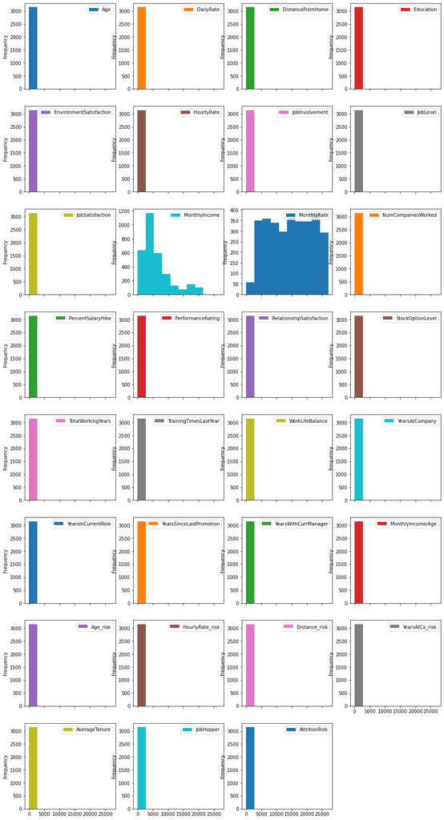

```python
# Histograms for each attribute
df_features_train.plot(kind='hist', subplots=True, layout=(display_rows, display_columns))
plt.show()
```

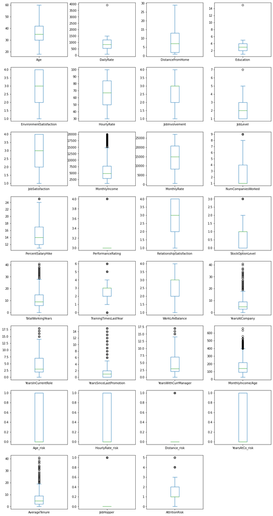

```python
# Box and Whisker plot for each attribute
df_features_train.plot(kind='box', subplots=True, layout=(display_rows, display_columns))
plt.show()
```

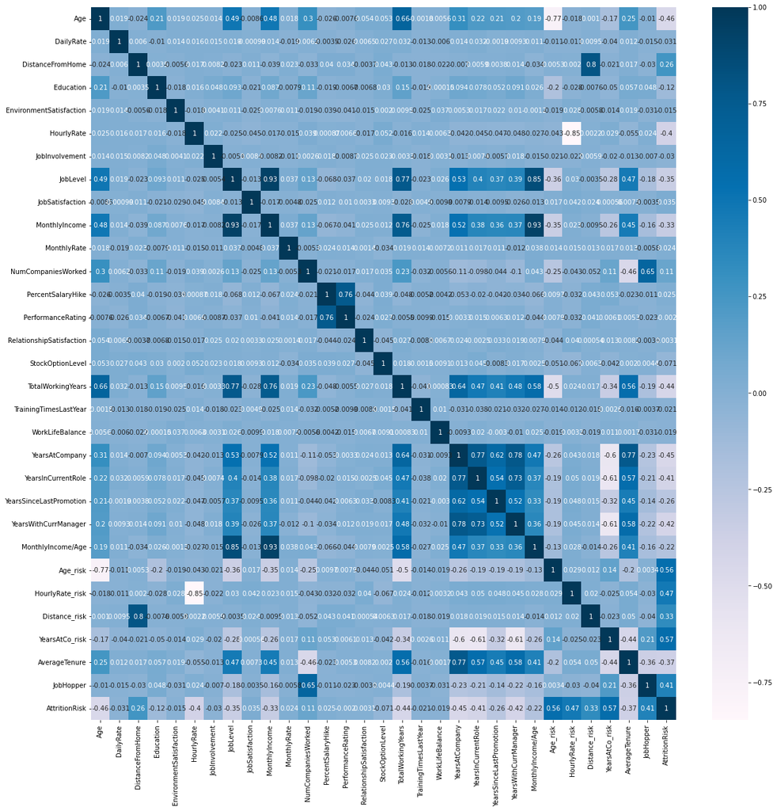

```python
# Correlation matrix
fig = plt.figure(figsize=(20, 20))
correlations = df_features_train.corr(method='pearson')
sns.heatmap(correlations, annot=True, cmap=plt.cm.PuBu)
plt.show()
```

```python
if NOTIFY_STATUS: status_notify("Task 2 - Summarize and Visualize Data completed! "+datetime.now().strftime('%a %B %d, %Y %I:%M:%S %p'))
```

## Task 3 - Train and Evaluate Models

```python
if NOTIFY_STATUS: status_notify("Task 3 - Train and Evaluate Models has begun! "+datetime.now().strftime('%a %B %d, %Y %I:%M:%S %p'))
```

### 3.a) Splitting Data into Training and Validation Sets

```python
# Finalize the training and validation datasets for the modeling activities
tfds_train = tfdf.keras.pd_dataframe_to_tf_dataset(df_dataset_import, label='target', task = tfdf.keras.Task.CLASSIFICATION)
```

### 3.b) Train and Evaluate the Random Forest Model

```python
# Initialize the default model and get a baseline result
start_time_module = datetime.now()
tf.keras.utils.set_random_seed(RNG_SEED)
RF_model = tfdf.keras.RandomForestModel(task = tfdf.keras.Task.CLASSIFICATION)
RF_model.compile(metrics=DEFAULT_METRICS)
RF_model.fit(x=tfds_train)
print('Total time for model fitting:', (datetime.now() - start_time_module))
```

```
Use /tmp/tmptlekhdhd as temporary training directory
Reading training dataset...
```

[output not shown]

```
Training dataset read in 0:00:03.954624. Found 3147 examples.
Training model...
Model trained in 0:00:01.571712
Compiling model...
```

[output not shown]

[output not shown]

```python
RF_model.evaluate(tfds_train)
```

```
[0.0, 0.9991754293441772]
```

```python
RF_model.summary()
```

```
Model: "random_forest_model"
_________________________________________________________________
 Layer (type)                Output Shape              Param #
=================================================================
=================================================================
Total params: 1
Trainable params: 0
Non-trainable params: 1
_________________________________________________________________
Type: "RANDOM_FOREST"
Task: CLASSIFICATION
Label: "__LABEL"

Input Features (39):
	Age
	Age_risk
	AttritionRisk
	AverageTenure
	BusinessTravel
	DailyRate
	Department
	DistanceFromHome
	Distance_risk
	Education
	EducationField
	EnvironmentSatisfaction
	Gender
	HourlyRate
	HourlyRate_risk
	JobHopper
	JobInvolvement
	JobLevel
	JobRole
	JobSatisfaction
	MaritalStatus
	MonthlyIncome
	MonthlyIncome/Age
	MonthlyRate
	NumCompaniesWorked
	Over18
```

[output cut: 479 more lines]

```
	trees: 161, Out-of-bag evaluation: accuracy:0.877661 logloss:0.350972
	trees: 171, Out-of-bag evaluation: accuracy:0.877979 logloss:0.350754
	trees: 181, Out-of-bag evaluation: accuracy:0.877661 logloss:0.35019
	trees: 191, Out-of-bag evaluation: accuracy:0.877979 logloss:0.349502
	trees: 201, Out-of-bag evaluation: accuracy:0.878297 logloss:0.349476
	trees: 211, Out-of-bag evaluation: accuracy:0.877343 logloss:0.348973
	trees: 221, Out-of-bag evaluation: accuracy:0.87639 logloss:0.33866
	trees: 231, Out-of-bag evaluation: accuracy:0.877026 logloss:0.328014
	trees: 241, Out-of-bag evaluation: accuracy:0.877026 logloss:0.327838
	trees: 251, Out-of-bag evaluation: accuracy:0.877661 logloss:0.327598
	trees: 261, Out-of-bag evaluation: accuracy:0.877661 logloss:0.327773
	trees: 271, Out-of-bag evaluation: accuracy:0.877979 logloss:0.307804
	trees: 281, Out-of-bag evaluation: accuracy:0.877343 logloss:0.308535
	trees: 291, Out-of-bag evaluation: accuracy:0.877661 logloss:0.308141
	trees: 300, Out-of-bag evaluation: accuracy:0.877343 logloss:0.307854
```

### 3.c) Train and Evaluate the Decision Trees Model

```python
# Initialize the default model and get a baseline result
start_time_module = datetime.now()
tf.keras.utils.set_random_seed(RNG_SEED)
CART_model = tfdf.keras.CartModel(task = tfdf.keras.Task.CLASSIFICATION)
CART_model.compile(metrics=DEFAULT_METRICS)
CART_model.fit(x=tfds_train)
print('Total time for model fitting:', (datetime.now() - start_time_module))
```

```
Use /tmp/tmptsnjz4xs as temporary training directory
Reading training dataset...
Training dataset read in 0:00:00.386142. Found 3147 examples.
Training model...
Model trained in 0:00:00.038522
Compiling model...
Model compiled.
Total time for model fitting: 0:00:00.744598
```

```python
CART_model.evaluate(tfds_train)
```

```
[0.0, 0.9115390181541443]
```

```python
CART_model.summary()
```

```
Model: "cart_model"
_________________________________________________________________
 Layer (type)                Output Shape              Param #
=================================================================
=================================================================
Total params: 1
Trainable params: 0
Non-trainable params: 1
_________________________________________________________________
Type: "RANDOM_FOREST"
Task: CLASSIFICATION
Label: "__LABEL"

Input Features (39):
	Age
	Age_risk
	AttritionRisk
	AverageTenure
	BusinessTravel
	DailyRate
	Department
	DistanceFromHome
	Distance_risk
	Education
	EducationField
	EnvironmentSatisfaction
	Gender
	HourlyRate
	HourlyRate_risk
	JobHopper
	JobInvolvement
	JobLevel
	JobRole
	JobSatisfaction
	MaritalStatus
	MonthlyIncome
	MonthlyIncome/Age
	MonthlyRate
	NumCompaniesWorked
	Over18
```

[output cut: 203 more lines]

```
Condition type in nodes with depth <= 0:
	1 : HigherCondition
Condition type in nodes with depth <= 1:
	3 : HigherCondition
Condition type in nodes with depth <= 2:
	4 : HigherCondition
	2 : ContainsBitmapCondition
Condition type in nodes with depth <= 3:
	6 : HigherCondition
	3 : ContainsBitmapCondition
Condition type in nodes with depth <= 5:
	12 : HigherCondition
	6 : ContainsBitmapCondition
Node format: NOT_SET
Pruned nodes during training: 350
```

### 3.d) Train and Evaluate the Gradient Boosted Trees Model

```python
# Initialize the default model and get a baseline result
start_time_module = datetime.now()
tf.keras.utils.set_random_seed(RNG_SEED)
GBT_model = tfdf.keras.GradientBoostedTreesModel(task = tfdf.keras.Task.CLASSIFICATION)
GBT_model.compile(metrics=DEFAULT_METRICS)
GBT_model.fit(x=tfds_train)
print('Total time for model fitting:', (datetime.now() - start_time_module))
```

```
Use /tmp/tmp2rzytfq3 as temporary training directory
Reading training dataset...
Training dataset read in 0:00:00.409817. Found 3147 examples.
Training model...
Model trained in 0:00:02.861735
Compiling model...
Model compiled.
Total time for model fitting: 0:00:05.517806
```

```python
GBT_model.evaluate(tfds_train)
```

```
[0.0, 0.9457201361656189]
```

```python
GBT_model.summary()
```

```
Model: "gradient_boosted_trees_model"
_________________________________________________________________
 Layer (type)                Output Shape              Param #
=================================================================
=================================================================
Total params: 1
Trainable params: 0
Non-trainable params: 1
_________________________________________________________________
Type: "GRADIENT_BOOSTED_TREES"
Task: CLASSIFICATION
Label: "__LABEL"

Input Features (39):
	Age
	Age_risk
	AttritionRisk
	AverageTenure
	BusinessTravel
	DailyRate
	Department
	DistanceFromHome
	Distance_risk
	Education
	EducationField
	EnvironmentSatisfaction
	Gender
	HourlyRate
	HourlyRate_risk
	JobHopper
	JobInvolvement
	JobLevel
	JobRole
	JobSatisfaction
	MaritalStatus
	MonthlyIncome
	MonthlyIncome/Age
	MonthlyRate
	NumCompaniesWorked
	Over18
```

[output cut: 436 more lines]

```
	Iter:2 train-loss:0.701386 valid-loss:0.800167  train-accuracy:0.862869 valid-accuracy:0.844885
	Iter:3 train-loss:0.669972 valid-loss:0.785171  train-accuracy:0.862869 valid-accuracy:0.844885
	Iter:4 train-loss:0.644748 valid-loss:0.762385  train-accuracy:0.863221 valid-accuracy:0.844885
	Iter:5 train-loss:0.622053 valid-loss:0.749056  train-accuracy:0.867792 valid-accuracy:0.848185
	Iter:6 train-loss:0.601794 valid-loss:0.739607  train-accuracy:0.875527 valid-accuracy:0.858086
	Iter:16 train-loss:0.469739 valid-loss:0.670637  train-accuracy:0.908228 valid-accuracy:0.854786
	Iter:26 train-loss:0.388150 valid-loss:0.640322  train-accuracy:0.934599 valid-accuracy:0.841584
	Iter:36 train-loss:0.330330 valid-loss:0.621631  train-accuracy:0.947609 valid-accuracy:0.864686
	Iter:46 train-loss:0.289676 valid-loss:0.618699  train-accuracy:0.958158 valid-accuracy:0.871287
	Iter:56 train-loss:0.258249 valid-loss:0.604937  train-accuracy:0.966245 valid-accuracy:0.871287
	Iter:66 train-loss:0.227376 valid-loss:0.595040  train-accuracy:0.974332 valid-accuracy:0.867987
	Iter:76 train-loss:0.204396 valid-loss:0.590017  train-accuracy:0.977145 valid-accuracy:0.861386
	Iter:86 train-loss:0.187141 valid-loss:0.585359  train-accuracy:0.980661 valid-accuracy:0.871287
	Iter:96 train-loss:0.167320 valid-loss:0.588438  train-accuracy:0.982771 valid-accuracy:0.871287
	Iter:106 train-loss:0.149169 valid-loss:0.590260  train-accuracy:0.986287 valid-accuracy:0.874587
```

```python
if NOTIFY_STATUS: status_notify("Task 4 - Train and Evaluate Models completed! "+datetime.now().strftime('%a %B %d, %Y %I:%M:%S %p'))
```

## Task 4 - Fine-tune and Improve Models

```python
if NOTIFY_STATUS: status_notify("Task 4 - Fine-tune and Improve Models has begun! "+datetime.now().strftime('%a %B %d, %Y %I:%M:%S %p'))
```

```python
# Not applicable for this iteration of modeling
```

```python
if NOTIFY_STATUS: status_notify("Task 4 - Fine-tune and Improve Models completed! "+datetime.now().strftime('%a %B %d, %Y %I:%M:%S %p'))
```

## Task 5 - Finalize Model and Present Analysis

```python
if NOTIFY_STATUS: status_notify("Task 5 - Finalize Model and Present Analysis has begun! "+datetime.now().strftime('%a %B %d, %Y %I:%M:%S %p'))
```

### 5.a) Train the Final Model

```python
# Define the baseline model for benchmarking
start_time_module = datetime.now()
tf.keras.utils.set_random_seed(RNG_SEED)
final_model = tfdf.keras.RandomForestModel(task = tfdf.keras.Task.CLASSIFICATION)
# final_model = tfdf.keras.CartModel(task = tfdf.keras.Task.CLASSIFICATION)
# final_model = tfdf.keras.GradientBoostedTreesModel(task = tfdf.keras.Task.CLASSIFICATION)
final_model.compile(metrics=DEFAULT_METRICS)

# Train the model.
final_model.fit(x=tfds_train)
print ('Model training time:', (datetime.now() - start_time_module), '\n')
```

```
Use /tmp/tmpxa4gm48m as temporary training directory
Reading training dataset...
Training dataset read in 0:00:00.430991. Found 3147 examples.
Training model...
Model trained in 0:00:01.606221
Compiling model...
Model compiled.
Model training time: 0:00:02.399204
```

```python
final_model.summary()
```

```
Model: "random_forest_model_1"
_________________________________________________________________
 Layer (type)                Output Shape              Param #
=================================================================
=================================================================
Total params: 1
Trainable params: 0
Non-trainable params: 1
_________________________________________________________________
Type: "RANDOM_FOREST"
Task: CLASSIFICATION
Label: "__LABEL"

Input Features (39):
	Age
	Age_risk
	AttritionRisk
	AverageTenure
	BusinessTravel
	DailyRate
	Department
	DistanceFromHome
	Distance_risk
	Education
	EducationField
	EnvironmentSatisfaction
	Gender
	HourlyRate
	HourlyRate_risk
	JobHopper
	JobInvolvement
	JobLevel
	JobRole
	JobSatisfaction
	MaritalStatus
	MonthlyIncome
	MonthlyIncome/Age
	MonthlyRate
	NumCompaniesWorked
	Over18
```

[output cut: 479 more lines]

```
	trees: 161, Out-of-bag evaluation: accuracy:0.877661 logloss:0.350972
	trees: 171, Out-of-bag evaluation: accuracy:0.877979 logloss:0.350754
	trees: 181, Out-of-bag evaluation: accuracy:0.877661 logloss:0.35019
	trees: 191, Out-of-bag evaluation: accuracy:0.877979 logloss:0.349502
	trees: 201, Out-of-bag evaluation: accuracy:0.878297 logloss:0.349476
	trees: 211, Out-of-bag evaluation: accuracy:0.877343 logloss:0.348973
	trees: 221, Out-of-bag evaluation: accuracy:0.87639 logloss:0.33866
	trees: 231, Out-of-bag evaluation: accuracy:0.877026 logloss:0.328014
	trees: 241, Out-of-bag evaluation: accuracy:0.877026 logloss:0.327838
	trees: 251, Out-of-bag evaluation: accuracy:0.877661 logloss:0.327598
	trees: 261, Out-of-bag evaluation: accuracy:0.877661 logloss:0.327773
	trees: 271, Out-of-bag evaluation: accuracy:0.877979 logloss:0.307804
	trees: 281, Out-of-bag evaluation: accuracy:0.877343 logloss:0.308535
	trees: 291, Out-of-bag evaluation: accuracy:0.877661 logloss:0.308141
	trees: 300, Out-of-bag evaluation: accuracy:0.877343 logloss:0.307854
```

### 5.b) Load Test Dataset and Make Predictions

```python
df_features_test = pd.read_csv(TEST_DATASET)
# df_features_test['is_synthetic'] = 1

# Drop the columns that has no predictive value
df_features_test.drop(columns=['EmployeeCount','StandardHours'], inplace=True)

# Take a peek at the dataframe after import
print(df_features_test.head())
```

```
     id  Age     BusinessTravel  DailyRate              Department  \
0  1677   19         Non-Travel        992  Research & Development
1  1678   45      Travel_Rarely       1136                   Sales
2  1679   37      Travel_Rarely        155  Research & Development
3  1680   32      Travel_Rarely        688  Research & Development
4  1681   29  Travel_Frequently        464  Research & Development

   DistanceFromHome  Education EducationField  EnvironmentSatisfaction Gender  \
0                 1          1        Medical                        4   Male
1                 4          4      Marketing                        3   Male
2                13          3  Life Sciences                        4   Male
3                 1          4  Life Sciences                        3   Male
4                 9          1  Life Sciences                        3   Male

   ...  PerformanceRating  RelationshipSatisfaction  StockOptionLevel  \
```

[output cut: 21 more lines]

```python
df_features_test.info(verbose=True)
```

```
<class 'pandas.core.frame.DataFrame'>
RangeIndex: 1119 entries, 0 to 1118
Data columns (total 32 columns):
 #   Column                    Non-Null Count  Dtype
---  ------                    --------------  -----
 0   id                        1119 non-null   int64
 1   Age                       1119 non-null   int64
 2   BusinessTravel            1119 non-null   object
 3   DailyRate                 1119 non-null   int64
 4   Department                1119 non-null   object
 5   DistanceFromHome          1119 non-null   int64
 6   Education                 1119 non-null   int64
 7   EducationField            1119 non-null   object
 8   EnvironmentSatisfaction   1119 non-null   int64
 9   Gender                    1119 non-null   object
```

[output cut: 24 more lines]

```python
id_column_name = df_features_test.columns[0]
df_kaggle_submission = pd.DataFrame()
df_kaggle_submission[id_column_name] = df_features_test[id_column_name]
print(df_kaggle_submission.head())
```

```
     id
0  1677
1  1678
2  1679
3  1680
4  1681
```

```python
# Dropping unique identifier and unnecessary features
df_features_test.drop(columns=[id_column_name,], inplace=True)

# Apply additional feature engineering tasks suggested by the top competitor
df_features_test['MonthlyIncome/Age'] = df_features_test['MonthlyIncome'] / df_features_test['Age']
df_features_test["Age_risk"] = (df_features_test["Age"] < 34).astype(int)
df_features_test["HourlyRate_risk"] = (df_features_test["HourlyRate"] < 60).astype(int)
df_features_test["Distance_risk"] = (df_features_test["DistanceFromHome"] >= 20).astype(int)
df_features_test["YearsAtCo_risk"] = (df_features_test["YearsAtCompany"] < 4).astype(int)
df_features_test['NumCompaniesWorked'] = df_features_test['NumCompaniesWorked'].replace(0, 1)
df_features_test['AverageTenure'] = df_features_test["TotalWorkingYears"] / df_features_test["NumCompaniesWorked"]
df_features_test['JobHopper'] = ((df_features_test["NumCompaniesWorked"] > 2) & (df_features_test["AverageTenure"] < 2.0)).astype(int)
df_features_test["AttritionRisk"] = df_features_test["Age_risk"] + df_features_test["HourlyRate_risk"] + df_features_test["Distance_risk"] + df_features_test["YearsAtCo_risk"] + df_features_test['JobHopper']

# Take a peek at the dataframe after cleaning
print(df_features_test.head())
```

```
   Age     BusinessTravel  DailyRate              Department  \
0   19         Non-Travel        992  Research & Development
1   45      Travel_Rarely       1136                   Sales
2   37      Travel_Rarely        155  Research & Development
3   32      Travel_Rarely        688  Research & Development
4   29  Travel_Frequently        464  Research & Development

   DistanceFromHome  Education EducationField  EnvironmentSatisfaction Gender  \
0                 1          1        Medical                        4   Male
1                 4          4      Marketing                        3   Male
2                13          3  Life Sciences                        4   Male
3                 1          4  Life Sciences                        3   Male
4                 9          1  Life Sciences                        3   Male

   HourlyRate  ...  YearsSinceLastPromotion  YearsWithCurrManager  \
```

[output cut: 21 more lines]

```python
# Finalize the test dataset for the testing activities
tfds_test = tfdf.keras.pd_dataframe_to_tf_dataset(df_features_test, task = tfdf.keras.Task.CLASSIFICATION)
```

```python
# Make batched predictions
test_predictions =  final_model.predict(tfds_test)
print(test_predictions)
```

[output not shown]

```
[[0.3233331 ]
 [0.16666658]
 [0.08999998]
 ...
 [0.02      ]
 [0.02      ]
 [0.05333334]]
```

```python
df_sample_submission = pd.read_csv(SUBMISSION_TEMPLATE)
df_sample_submission.drop(columns=[id_column_name], inplace=True)
submission_header = list(df_sample_submission.columns)[0]
print(submission_header)
```

```
Attrition
```

```python
df_kaggle_submission[submission_header] = test_predictions
df_kaggle_submission[submission_header] = df_kaggle_submission[submission_header]
print(df_kaggle_submission.head())
```

```
     id  Attrition
0  1677   0.323333
1  1678   0.166667
2  1679   0.090000
3  1680   0.020000
4  1681   0.473333
```

```python
submission_file = df_kaggle_submission.to_csv(header=True, index=False)
filename = SUBMISSION_FILE + datetime.now().strftime('%Y%m%d-%H%M') + '.csv'
with open(filename, 'w') as f:
    f.write(submission_file)
    print('Completed writing output file: ' + filename)
```

```
Completed writing output file: submission_decisionforests_20230127-1736.csv
```

```python
if NOTIFY_STATUS: status_notify("Task 5 - Finalize Model and Present Analysis completed! "+datetime.now().strftime('%a %B %d, %Y %I:%M:%S %p'))
```

```python
print ('Total time for the script:',(datetime.now() - start_time_script))
```

```
Total time for the script: 0:04:32.511261
```